# FINAL PROJECT: HIGH DIMENSIONAL ANALYSIS

Members:

- 19110348: Đỗ Khánh Đăng Khoa
- 19110522: Bùi Thị Thanh Xuân
- 19110414: Võ Hoàng Phúc

```python
#import library
import torch
import torch.nn as nn
import torch.optim as optim
import torch.nn.functional as F
from torch.autograd import Variable as V

import matplotlib
import pandas as pd
import numpy as np
import matplotlib.pylab as plt
from matplotlib import cm
import seaborn as sns

import seaborn as sns
from sklearn.metrics import accuracy_score, rand_score, silhouette_score,davies_bouldin_score
from sklearn.utils import shuffle
from sklearn.preprocessing import StandardScaler
from sklearn.cluster import KMeans, SpectralClustering, AgglomerativeClustering
from sklearn.decomposition import PCA, KernelPCA, FastICA
from sklearn.manifold import TSNE
from sklearn.preprocessing import StandardScaler as scale

from scipy.spatial.distance import cdist
from scipy.spatial import distance
import random

import glob
import os
from scipy.linalg import eigh
from scipy.spatial.distance import pdist, squareform
from scipy import exp
from mpl_toolkits.mplot3d import Axes3D
import time

matplotlib.style.use('ggplot')
%matplotlib inline
```

```python
# Mount drive
from google.colab import drive
drive.mount('/content/gdrive')
```

```python
root = "/content/gdrive/MyDrive/XLĐC/HMP_Dataset/"
checkPath = os.path.isdir(root)
print("The path and file are valid or not :", checkPath)
```

```
The path and file are valid or not : True
```

# READ LABEL AND DATASET

```python
dict_wrist = {'Brush_teeth':0, 'Climb_stairs':1, 'Comb_hair':2, 'Descend_stairs':3, 'Drink_glass':4,
              'Eat_meat':5,'Eat_soup':6,'Getup_bed':7,'Liedown_bed':8,'Pour_water':9,'Sitdown_chair':10,
              'Standup_chair':11,'Use_telephone':12,'Walk':13 }

def read_file(dict_wrist):
    '''
        Hàm đọc file
        -----------------
        Tham số:
            class_dict: một dictionary chứa 14 hành động được gán nhãn từ 0 đến 13
        -----------------
        Trả về:
            X: một list có len = 14 chứa dữ liệu đã được đọc (Mỗi phần tử của list có dạng numpy array chứa các sample của nhãn đó)
    '''
    X = []
    for c in dict_wrist.keys():
        f = glob.glob(root + c + '/*')
        d = read_each_file(f, cls=c)
        X.append(d)
    return X #type list

def read_each_file(files, cls):
    temp = []
    for f in files:
        data = pd.read_table(f, sep=' ', header=None)
        data = np.array(data)
        temp.append(data)
    return temp

def prepare_data(data):
    '''
        Hàm tách features và labels
        ---------------------------
        Tham số:
            data: list chứa các dữ liệu vừa được đọc
         ---------------------------------------------
        idx| size | value                            |
        ----------------------------------------------
        0  |  12  | (2167,3), (844,3), ...           |
        ----------------------------------------------
        1  | 102  | (270,3) , (270,3), ...           |
        ----------------------------------------------
        2  |  31  | ...                              |
        ----------------------------------------------
        3  |  42  | ...                              |
        ----------------------------------------------
        .  | ...  |
        .  | ...  | ...                              |
        .  | ...  |
        ----------------------------------------------
        13 | 100  | (1170,3), (956,3)                |
        ----------------------------------------------
        Trả về:
            X: list có chiều dài là 839, tương ứng 839 samples
            y: 839 labels
        ---------------------------------------------
        idx| size                                   |
        ----------------------------------------------
        0   |  (2167,3)                              |
        ----------------------------------------------
        1   |  (844,3)                               |
        ----------------------------------------------
        2   |  (2228,3)                              |
        ----------------------------------------------
        3   |                                        |
        ----------------------------------------------
        .   | ...
        .   | ...                                    |
        .   | ...
        ----------------------------------------------
        838 | (1050,3)                               |
        ----------------------------------------------
    '''
    X = []
    y = []
    for i,f in enumerate(data): #i chạy từ 0 đến 13, f
        for ii in f:
            X.append(ii)
            y.append(i)
    return X, y
```

```python
temp_X = read_file(dict_wrist)
X,original_label = prepare_data(temp_X)
```

# PREPROCESSING DATA

Trích chọn đặc trưng theo tiêu chí mean, std, min, max

Mô tả dữ liệu:

- X có 839 samples
- Mỗi sample là kx3 (k không cố định)
- Từng sample có 3 cột (hay features của từng sample): x,y,z

Bước 1: Trích chọn đặc trưng theo tiêu chí mean, std, min, max

1. Xác định đặc trưng thống kê cần rút trích ở đây ta chọn 1 trong 4 đặc trưng sau: mean, std, max, min
2. Sử dụng đặc trưng thống kê đã chọn ở B1 thực hiện tính toán trên các chiều lần lượt Ox, Oy, Oz. Kết quả thu được có số chiều bằng 3
3. Thay thế dữ liệu ban đầu bằng dữ liệu đã xử lý ở B2

Bước 2: Chuyển từng sample thành vector k chiều, tức trong bài là vector 12 chiều

- Cuối cùng dữ liệu của chúng ta có được là một numpy array: (839x12)

Chi tiết:

Bước 1: Trích chọn đặc trưng theo tiêu chí mean, std, min, max.

```python
def extract_feature(X):
    '''
    Hàm Trích chọn đặc trưng theo tiêu chí mean, std, min, max.
    ---------------------------------
    Tham số:
        X: list có chiều dài là 839, tương ứng 839 samples
    ---------------------------------
    Trả về:
        temp: list có chiều dài 839, mỗi phần tử là một numpy array có shape là (1,12)
    '''
    temp = []
    for arr in X:
        a = (np.mean(arr,axis =0)).reshape(1,3)
        b = (np.std(arr,axis =0)).reshape(1,3)
        c = (np.max(arr,axis =0)).reshape(1,3)
        d = (np.min(arr,axis =0)).reshape(1,3)
        temp.append(np.concatenate((a, b, c, d), axis=1))
    return temp
```

```python
X_new = extract_feature(X)
```

Bước 2: Chuyển từng sample thành vector k chiều, tức trong bài là vector 12 chiều

```python
def vectorization(X):
    '''
    Hàm Chuyển từng sample thành vector (12,) chiều
    ---------------------------------------------------
    Tham số:
        X: list có chiều dài 839, mỗi phần tử là một nummpy array có dạng (1,12)
        ----------------------
        idx |   size(1,12) |
        ----------------------
        0   |  (1,12)      |
        ----------------------
        1   |  (1,12)      |
        ----------------------
        2   |  (1,12)      |
        ----------------------
        3   | ...          |
        ----------------------
        .   | ...          |
        .   | ...          |
        ----------------------
        838 |  (1,12)      |
        ------------------------------------------------
    Trả về:
        X: list có chiều dài 839, mỗi phần tử là một nummpy array có dạng (12,)
        ----------------------
        idx |   size(12,) |
        ----------------------
        0   |  (12,)      |
        ----------------------
        1   |  (12,)      |
        ----------------------
        2   |  (12,)      |
        ----------------------
        3   | ...         |
        ----------------------
        .   | ...         |
        .   | ...         |
        ----------------------
        838 |  (12,)      |
        ----------------------
    '''
    for i in range(len(X)):
        X[i] = X[i].flatten()
    return X
```

```python
X_vector = vectorization(X_new)
```

```python
#Print thử data
df = pd.DataFrame (X_vector, columns = ['mean_x','mean_y','mean_z','std_x','std_y',
                                        'std_z','max_x','max_y','max_z','min_x','min_y','min_z'])
df.head()
```

|  | mean_x | mean_y | mean_z | std_x | std_y | std_z | max_x | max_y | max_z | min_x | min_y | min_z |
| --- | --- | --- | --- | --- | --- | --- | --- | --- | --- | --- | --- | --- |
| 0 | 26.549146 | 49.857407 | 36.037840 | 9.470926 | 8.657694 | 7.145430 | 60.0 | 63.0 | 52.0 | 0.0 | 16.0 | 12.0 |
| 1 | 25.021327 | 48.443128 | 38.065166 | 9.227998 | 8.827485 | 6.737408 | 59.0 | 63.0 | 52.0 | 0.0 | 15.0 | 17.0 |
| 2 | 29.531418 | 50.287702 | 33.451526 | 9.735570 | 8.362860 | 9.604424 | 63.0 | 63.0 | 57.0 | 0.0 | 15.0 | 0.0 |
| 3 | 29.737402 | 50.361997 | 33.208044 | 9.338125 | 8.749283 | 9.702138 | 63.0 | 63.0 | 56.0 | 0.0 | 14.0 | 3.0 |
| 4 | 35.554236 | 48.988121 | 38.094092 | 11.612375 | 7.855358 | 5.571516 | 63.0 | 63.0 | 61.0 | 0.0 | 20.0 | 21.0 |

```python
# To numpy array
features = np.array(X_vector)
original_label = np.array(original_label)

#Print shape of features and original_label
print(features.shape)
print(original_label.shape)
```

```
(839, 12)
(839,)
```

Kmeans sử dụng thư viện khi chưa giảm số chiều

```python
#Train
kmean_data = KMeans(n_clusters=14).fit(features)

#Predict
clusters_data = kmean_data.predict(features)
```

```python
# Start checking time spent for testing Kmeans use statistical features
time_start = time.time()

#Accuracy
y_data_accuracy = accuracy_score(original_label,clusters_data)

#rand_score
y_data_rand_score = rand_score(original_label,clusters_data)

#silhouette_score
y_data_silhouette_score = silhouette_score(features, clusters_data,
                                           metric = "euclidean", sample_size= 839)


#benchmark
score_table = pd.DataFrame.from_dict({'accuracy_score': [y_data_accuracy], 'rand_score': [y_data_rand_score],
                              'silhouette_score': [y_data_silhouette_score]}, orient='index',
                              columns=['score'])
# End checking time spent for testing Kmeans use statistical features
time_stat = time.time() - time_start
print('Kmean with padding done! Time elapsed: {} seconds'.format(time_stat))
print(score_table)
```

```
Kmean with padding done! Time elapsed: 0.023023128509521484 seconds
                     score
accuracy_score    0.103695
rand_score        0.872220
silhouette_score  0.251157
```

Sự khác nhau giữa các matric:

- accuracy_score:

  Trong bài toán phân loại đa nhãn, hàm này tính toán độ chính xác của tập hợp con: tập hợp nhãn được dự đoán cho một mẫu phải khớp chính xác với tập nhãn tương ứng trong y_true.
- rand_score:

  Chỉ số Rand tính toán độ đo tương tự giữa hai cụm bằng cách xem xét tất cả các cặp mẫu và đếm các cặp được chỉ định trong các cụm giống nhau hoặc khác nhau trong cụm được dự đoán và đúng.

  The raw RI score is:

  RI = (number of agreeing pairs) / (number of pairs)
- silhouette_score:

  Hệ số Silhouette được tính bằng cách sử dụng khoảng cách trung bình trong cụm ( a) và khoảng cách trung bình trong cụm gần nhất ( b) cho mỗi mẫu.

  Giá trị tốt nhất là 1 và giá trị kém nhất là -1. Các giá trị gần 0 cho biết các cụm chồng chéo. Các giá trị âm thường chỉ ra rằng một mẫu đã được chỉ định sai cụm, vì một cụm khác giống nhau hơn.

*Nhận xét:*

Qua Kmeans phân cụm dùng đặc trương thống kê dạng bảng và kiểm tra với các độ đo khác nhau chúng ta thấy:

- accuracy_score cho kết quả không tốt (0.103695) trên miền accuracy [0,1]. Điều này cho thấy đặc trưng thống kê dạng bảng được rút trích không tốt cho khía cạnh phân lớp.
- rand_score biểu diễn sự khoảng cách giữa các cụm. Khoảng cách càng xa thì rand_score càng nhỏ và khi rand_score nhỏ thì kết quả phân cụm mới đủ tốt. Tuy nhiên, với đặc trưng thống kê, rand_score lại cho kết quả ngược lại (0.872220), điều này cho thấy các cụm phân được bằng đặc trưng thống kê là gần nhau và không tốt cho quá trình phân cụm.
- silhouette_score có miền giá trị là [-1,1], biểu diễn khả năng 1 điểm dữ liệu có được phân cụm đúng hay không. Với đặc trưng thống kê, kết quả thu được là (0.251157). Độ tốt với khía cạnh phân cụm điểm dữ liệu là ở mức trung bình.
- > Kết luận: kết quả tính toán phân cụm dùng đặc trưng thống kê cho kết quả kém ở 2 trên 3 độ đo. Điều này cho thấy đặc trưng thống kê không tốt với bài toán phân cụm với dữ liệu dạng chuỗi.

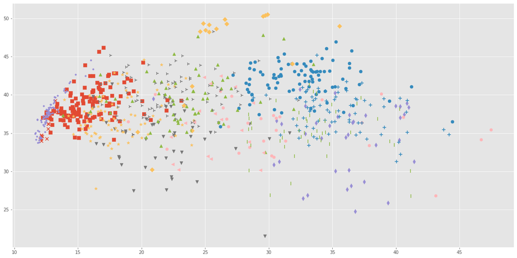

```python
#Visualization after using kmeans clutering
def data_visualization(X,y_pred):
    markers = ["s","o","d","v","*","^","h","x","+",".","4","D","|","<"]
    plt.figure(figsize=(20,10))
    for ii in range(14):
        plt.scatter(X[:,0][y_pred==ii], X[:,1][y_pred==ii],cmap='Set2',marker=markers[ii],s=50)
data_visualization(features,clusters_data)
```

Nhìn hình chúng ta thấy dữ liệu vẫn chưa phân cụm theo từng nhóm rõ ràng. Nó vẫn còn khá trộn lẫn vào nhau.

# Dimensionality reduction using PCA

```python
#suffle data
wrist_X, wrist_Y = shuffle(features,original_label, random_state=0)
```

```python
time_start = time.time()

pca = PCA(n_components=3)
pca_result = pca.fit_transform(wrist_X)

time_pca = time.time() - time_start
print('PCA done! Time elapsed: {} seconds'.format(time_pca))

#Projected
projected_1 = pca_result[:,0]
projected_2 = pca_result[:,1]
projected_3 = pca_result[:,2]
res = pd.DataFrame(projected_1, columns=['PC1'])
res['PC2'] = projected_2
res['PC3'] = projected_3
res['label'] = wrist_Y

print('Explained variation per principal component: {}'.format(pca.explained_variance_ratio_))
```

```
PCA done! Time elapsed: 0.03490138053894043 seconds
Explained variation per principal component: [0.43317364 0.29181852 0.10190177]
```

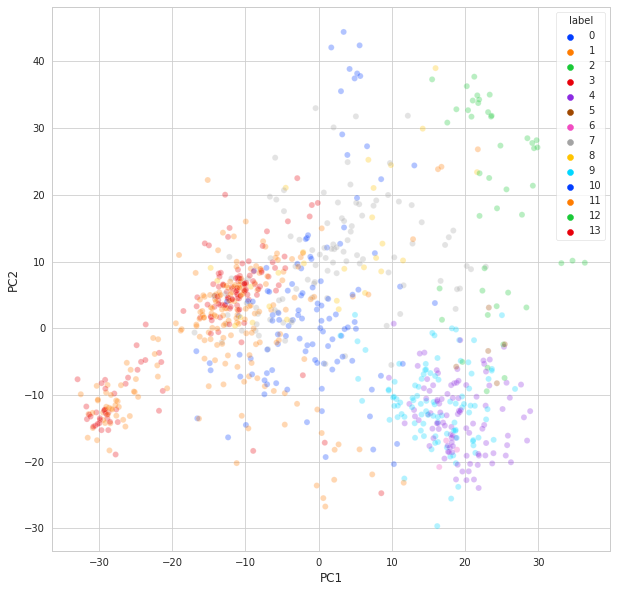

```python
sns.set_style("whitegrid")
plt.figure(figsize=(10,10))
sns.scatterplot(
    x="PC1", y="PC2",
    hue="label",
    data= res,
    palette = sns.color_palette("bright",14),
    legend="full",
    alpha=0.3
)
```

3 PC đầu chiếm khoảng 83%. Tuy nhiên, khi chiếu dữ liệu lên hai chiều, nó vẫn còn chồng chất lên nhau.

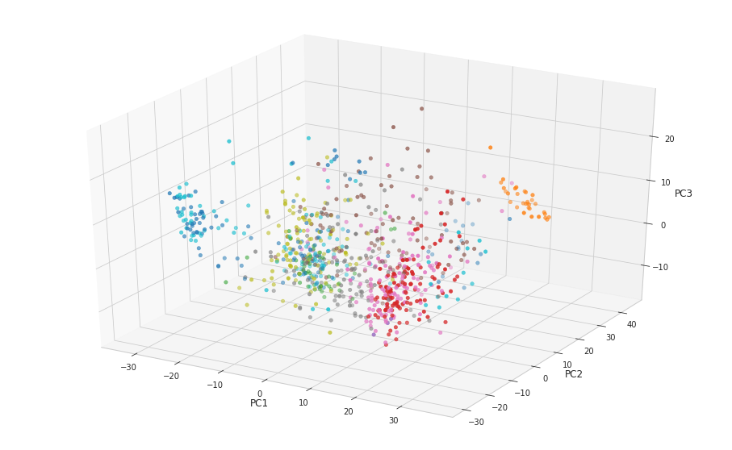

```python
ax = plt.figure(figsize=(16,10)).gca(projection='3d')
ax.scatter(
    xs=res["PC1"],
    ys=res["PC2"],
    zs=res["PC3"],
    c=res["label"],
    cmap='tab10'
)
ax.set_xlabel('PC1')
ax.set_ylabel('PC2')
ax.set_zlabel('PC3')
plt.show()
```

Vẽ thử dữ liệu lên 3 chiều, nó cũng vẫn còn chồng chất lên nhau.

## Kmeans with sklearn after using PCA

```python
#kmeans with sklearn

#Train
kmean_pca = KMeans(n_clusters=14).fit(pca_result)

#Predict
clusters_pca = kmean_pca.predict(pca_result)
```

```python
#Accuracy
y_pca_accuracy = accuracy_score(wrist_Y,clusters_pca)

#rand_score
y_pca_rand_score = rand_score(wrist_Y,clusters_pca)

#silhouette_score
y_pca_silhouette_score = silhouette_score(pca_result, clusters_pca,
                                           metric = "euclidean", sample_size= 839)

#benchmark
score_table = pd.DataFrame.from_dict({'accuracy_score': [y_pca_accuracy], 'rand_score': [y_pca_rand_score],
                              'silhouette_score': [y_pca_silhouette_score]}, orient='index',
                              columns=['score'])
score_table
```

|  | score |
| --- | --- |
| accuracy_score | 0.104887 |
| rand_score | 0.864437 |
| silhouette_score | 0.330348 |

*Nhận xét:*

Qua Kmeans phân cụm dùng đặc trưng PCA trên dữ liệu thống kê dạng bảng và kiểm định với các độ đo khác nhau chúng ta thấy:

- accuracy_score của đặc trưng đang xét là (0.104887) tốt hơn so với khi dùng kmean trên dữ liệu thống kê dạng bảng chưa qua giảm số chiều là (0.103695). Tuy nhiên, kết quả cũng không đủ tốt.
- rand_score của đặc trưng đang xét là (0.864437), tốt hơn so với đặc trưng trên tập dữ liệu thống kê dạng bảng là (0.872220). Tuy nhiên, kết quả cũng không đủ tốt.
- silhouette_score của đặc trưng đang xét là (0.330348), tốt hơn so với đặc trưng trên tập dữ liệu thống kê dạng bảng là (0.251157). Tuy nhiên, kết quả cũng chỉ đạt ở mức trung bình khá.
- > Kết luận: kết quả tính toán phân cụm dùng đặc trưng PCA trên dữ liệu thống kê dạng bảng cho kết quả kém ở 2 trên 3 độ đo.

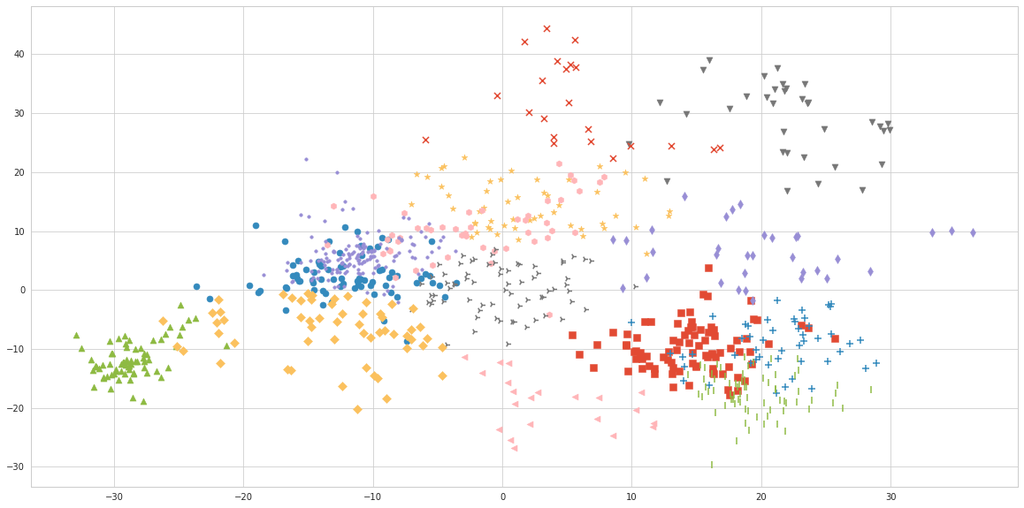

```python
#Visualization after using kmeans clutering
data_visualization(pca_result,clusters_pca)
```

Nhìn hình ta thấy dữ liệu vẫn còn chồng chất lên nhau, chưa phân cụm rõ ràng.

# Dimensionality reduction using t-SNE

```python
time_start = time.time()
tsne = TSNE(n_components=3, verbose=1,perplexity = 50,n_iter = 1000)
tsne_results = tsne.fit_transform(wrist_X)
time_tsne = time.time() - time_start
print('t-SNE done! Time elapsed: {} seconds'.format(time_tsne))
```

```
[t-SNE] Computing 151 nearest neighbors...
[t-SNE] Indexed 839 samples in 0.002s...
[t-SNE] Computed neighbors for 839 samples in 0.034s...
[t-SNE] Computed conditional probabilities for sample 839 / 839
[t-SNE] Mean sigma: 6.543595
[t-SNE] KL divergence after 250 iterations with early exaggeration: 57.088604
[t-SNE] KL divergence after 1000 iterations: 0.496207
t-SNE done! Time elapsed: 46.58813214302063 seconds
```

```python
tsne_1 = tsne_results[:,0]
tsne_2 = tsne_results[:,1]
res_tsne = pd.DataFrame(tsne_1, columns=['tsne-2d-one'])
res_tsne['tsne-2d-two'] = tsne_2
res_tsne['label'] = wrist_Y
```

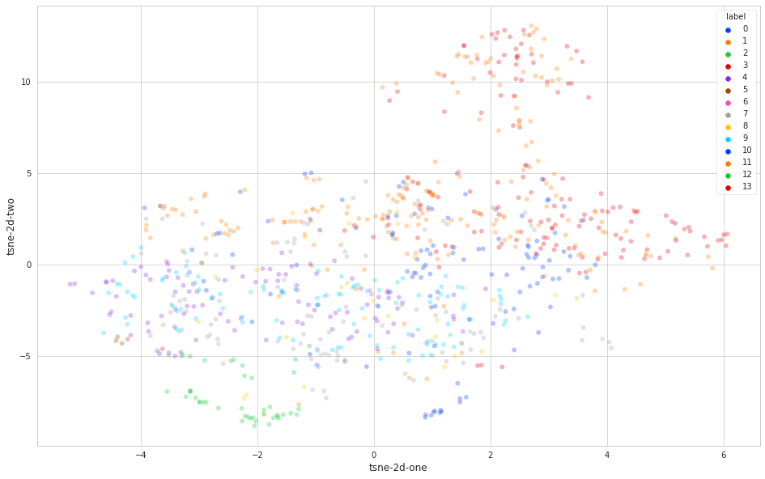

```python
plt.figure(figsize=(16,10))
sns.scatterplot(
    x="tsne-2d-one", y="tsne-2d-two",
    hue="label",
    palette = sns.color_palette("bright",14),
    data=res_tsne,
    legend="full",
    alpha=0.3
)
```

Nhìn hình ta thấy dữ liệu vẫn chồng chất lên nhau mặc dù đã thử nhiều lần với các perplexity, iteration khác nhau.

## Kmeans with sklearn after using t-SNE

```python
#Train
kmean_tsne = KMeans(n_clusters=14).fit(tsne_results)

#Predict
clusters_tsne = kmean_tsne.predict(tsne_results)
```

```python
#Accuracy
y_tsne_accuracy = accuracy_score(wrist_Y,clusters_tsne)

#rand_score
y_tsne_rand_score = rand_score(wrist_Y,clusters_tsne)

#silhouette_score
y_tsne_silhouette_score = silhouette_score(tsne_results, clusters_tsne,
                                           metric = "euclidean", sample_size= 839)

#benchmark
score_table = pd.DataFrame.from_dict({'accuracy_score': [y_tsne_accuracy], 'rand_score': [y_tsne_rand_score],
                              'silhouette_score': [y_tsne_silhouette_score]}, orient='index',
                              columns=['score'])
score_table
```

|  | score |
| --- | --- |
| accuracy_score | 0.097735 |
| rand_score | 0.877147 |
| silhouette_score | 0.385783 |

**Nhật xét:**

Qua Kmeans phân cụm dùng đặc trưng t-SNE trên dữ liệu thống kê dạng bảng và kiểm định với các độ đo khác nhau chúng ta thấy:

- accuracy_score của đặc trưng đang xét là (0.097735) kém hơn so với khi dùng kmean trên dữ liệu thống kê dạng bảng chưa qua giảm số chiều là (0.103695).
- rand_score của đặc trưng đang xét là (0.877147), kém hơn so với đặc trưng trên tập dữ liệu thống kê dạng bảng là (0.872220) (Do chỉ số rand_score càng cao thì độ chồng chéo giữa các cụm càng rõ rệt).
- silhouette_score của đặc trưng đang xét là (0.385783), tốt hơn so với đặc trưng trên tập dữ liệu thống kê dạng bảng là (0.251157). Tuy nhiên, kết quả cũng chỉ đạt ở mức trung bình khá.
- > Kết luận: kết quả tính toán phân cụm dùng đặc trưng t-SNE trên dữ liệu thống kê dạng bảng cho kết quả kém ở 2 trên 3 độ đo.

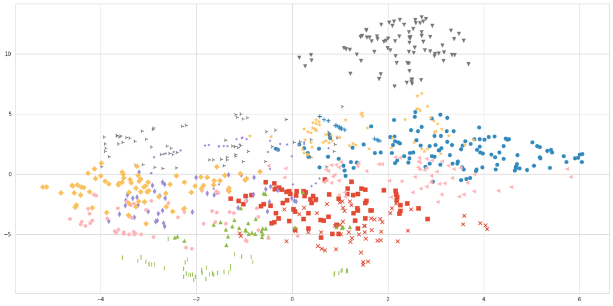

```python
#Visualization after using kmeans clutering
data_visualization(tsne_results,clusters_tsne)
```

Nhìn hình phân cụm ở mức trung bình, vẫn còn vài cụm chồng chất lên nhau.

# Dimensionality reduction using Kernel PCA

## KPCA với sklearn, kernel = "linear"

```python
#KPCA với sklearn, kernel = linear

time_start = time.time()
transformer = KernelPCA(n_components=3, kernel='linear')
X_transformed = transformer.fit_transform(wrist_X)

time_kpca = time.time() - time_start
print('t-SNE done! Time elapsed: {} seconds'.format(time_kpca))
```

```
t-SNE done! Time elapsed: 0.040848493576049805 seconds
```

```python
#kmeans after using KPCA with kernel = 'linear'

#Train
kmeans = KMeans(n_clusters=14).fit(X_transformed)

#Predict
clusters_kpca = kmeans.predict(X_transformed)
```

```python
#Accuracy
y_kpca_accuracy = accuracy_score(wrist_Y,clusters_kpca)

#rand_score
y_kpca_rand_score = rand_score(wrist_Y,clusters_kpca)

#silhouette_score
y_kpca_silhouette_score = silhouette_score(X_transformed, clusters_kpca,
                                           metric = "euclidean", sample_size= 839)

#benchmark
score_table = pd.DataFrame.from_dict({'accuracy_score': [y_kpca_accuracy], 'rand_score': [y_kpca_rand_score],
                              'silhouette_score': [y_kpca_silhouette_score]}, orient='index',
                              columns=['score'])
score_table
```

|  | score |
| --- | --- |
| accuracy_score | 0.160906 |
| rand_score | 0.864821 |
| silhouette_score | 0.323244 |

**Nhận xét**

Qua Kmeans phân cụm dùng đặc trưng KPCA (kernel = "linear") trên dữ liệu thống kê dạng bảng và kiểm định với các độ đo khác nhau chúng ta thấy:

- accuracy_score của đặc trưng đang xét là (0.160906) tốt hơn so với khi dùng kmean trên dữ liệu thống kê dạng bảng chưa qua giảm số chiều là (0.103695). Tuy nhiên, kết quả cũng không đủ tốt.
- rand_score của đặc trưng đang xét là (0.864821), tốt hơn so với đặc trưng trên tập dữ liệu thống kê dạng bảng là (0.872220). Tuy nhiên, kết quả cũng không đủ tốt.
- silhouette_score của đặc trưng đang xét là (0.323244), tốt hơn so với đặc trưng trên tập dữ liệu thống kê dạng bảng là (0.251157). Tuy nhiên, kết quả cũng chỉ đạt ở mức trung bình khá.
- > Kết luận: kết quả tính toán phân cụm dùng đặc trưng KPCA (kernel = "linear") trên dữ liệu thống kê dạng bảng cho kết quả vẫn kém ở 2 trên 3 độ đo dù cho các chỉ số cho thấy có cao hơn so với khi phân cụm trên dữ liệu đặc trưng chưa qua giảm số chiều

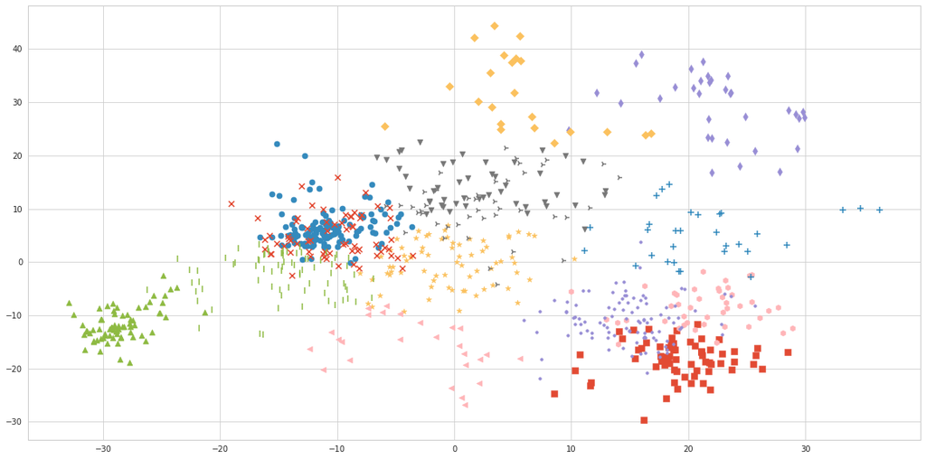

```python
#Visualization after using kmeans clutering
data_visualization(X_transformed,clusters_kpca)
```

Nhìn hình ta thấy, dữ liệu vẫn chưa phân cụm tốt.

## KPCA với sklearn, kernel = rbf

```python
#KPCA với sklearn, kernel = rbf

time_start = time.time()
X_KPCA = KernelPCA(n_components=3, kernel='rbf')
X_kpca = X_KPCA.fit_transform(wrist_X)

time_kpca_rbf = time.time() - time_start
print('t-SNE done! Time elapsed: {} seconds'.format(time_kpca_rbf))
```

```
t-SNE done! Time elapsed: 0.06776785850524902 seconds
```

```python
#kmeans after KPCA with kernel = 'rbf'

#Train
kmeans = KMeans(n_clusters=14).fit(X_kpca)

#Predict
clusters_Kpca = kmeans.predict(X_kpca)
```

```python
#Accuracy
y_Kpca_accuracy = accuracy_score(wrist_Y,clusters_Kpca)

#rand_score
y_Kpca_rand_score = rand_score(wrist_Y,clusters_Kpca)

#silhouette_score
y_Kpca_silhouette_score = silhouette_score(X_kpca, clusters_Kpca,
                                           metric = "euclidean", sample_size= 839)

#davies_bouldin_score
y_Kpca_bouldin_score = davies_bouldin_score(X_kpca, clusters_Kpca)

#benchmark
score_table = pd.DataFrame.from_dict({'accuracy_score': [y_Kpca_accuracy], 'rand_score': [y_Kpca_rand_score],
                              'silhouette_score': [y_Kpca_silhouette_score]}, orient='index',
                              columns=['score'])
score_table
```

|  | score |
| --- | --- |
| accuracy_score | 0.126341 |
| rand_score | 0.317750 |
| silhouette_score | 0.857750 |

**Nhận xét**

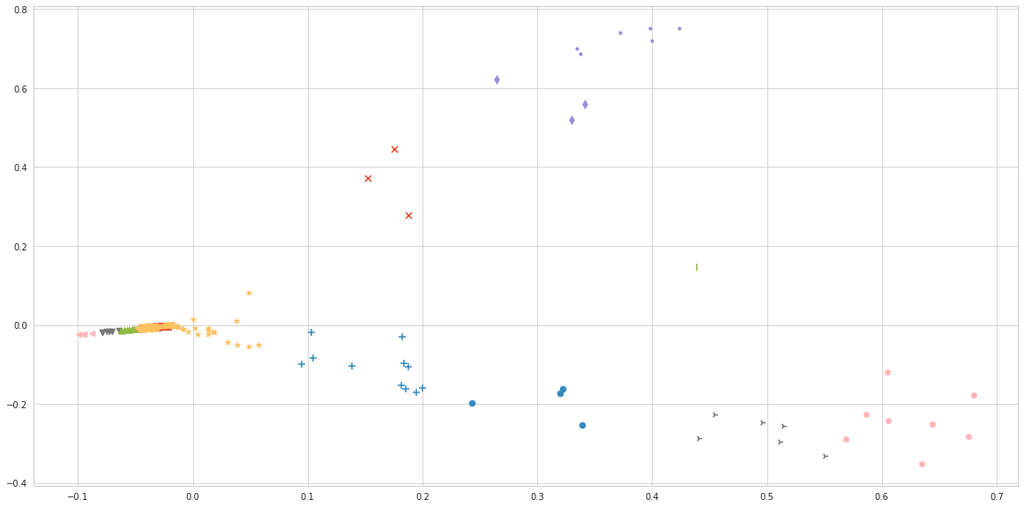

```python
#Visualization after using kmeans clutering
data_visualization(X_kpca,clusters_Kpca)
```

Nhìn hình ta thấy, kernel là rbf dữ liệu phân cụm tệ hơn nhiều so với khi sử dụng kernel là linear.

# Dimensionality reduction using ICA

```python
time_start = time.time()
ica = FastICA(n_components=3, max_iter=8000)
X_ica = ica.fit_transform(wrist_X)

time_ica = time.time() - time_start
print('ICA done! Time elapsed: {} seconds'.format(time_ica))
```

```
ICA done! Time elapsed: 0.023329973220825195 seconds
```

## Kmeans with sklearn after using ICA

```python
#Train
kmeans_ica = KMeans(n_clusters=14).fit(X_ica)

#Predict
clusters_ica = kmeans_ica.predict(X_ica)
```

```python
#Accuracy
y_ica_accuracy = accuracy_score(wrist_Y,clusters_ica)

#rand_score
y_ica_rand_score = rand_score(wrist_Y,clusters_ica)

#silhouette_score
y_ica_silhouette_score = silhouette_score(X_ica, clusters_ica,
                                           metric = "euclidean", sample_size= 839)

#benchmark
score_table = pd.DataFrame.from_dict({'accuracy_score': [y_ica_accuracy], 'rand_score': [y_ica_rand_score],
                              'silhouette_score': [y_ica_silhouette_score]}, orient='index',
                              columns=['score'])
score_table
```

|  | score |
| --- | --- |
| accuracy_score | 0.110846 |
| rand_score | 0.859738 |
| silhouette_score | 0.311246 |

**Nhận xét** Qua Kmeans phân cụm dùng đặc trưng ICA trên dữ liệu thống kê dạng bảng và kiểm định với các độ đo khác nhau chúng ta thấy:

- accuracy_score của đặc trưng đang xét là (0.110846) tốt hơn so với khi dùng kmean trên dữ liệu thống kê dạng bảng chưa qua giảm số chiều là (0.103695). Tuy nhiên, kết quả cũng không đủ tốt.
- rand_score của đặc trưng đang xét là (0.859738), tốt hơn so với đặc trưng trên tập dữ liệu thống kê dạng bảng là (0.872220). Tuy nhiên, kết quả cũng không đủ tốt.
- silhouette_score của đặc trưng đang xét là (0.311246), tốt hơn so với đặc trưng trên tập dữ liệu thống kê dạng bảng là (0.251157). Tuy nhiên, kết quả cũng chỉ đạt ở mức trung bình khá.
- > Kết luận: kết quả tính toán phân cụm dùng đặc trưng ICA trên dữ liệu thống kê dạng bảng cho kết quả kém ở 2 trên 3 độ đo.

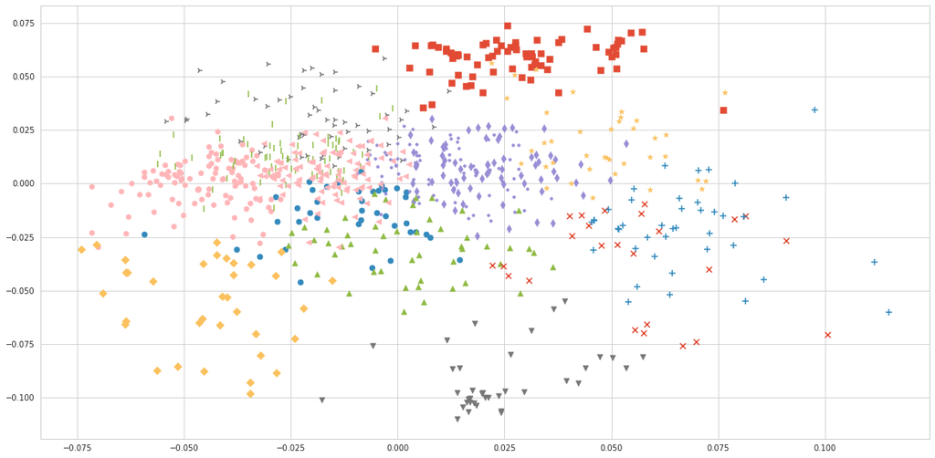

```python
#Visualization after using kmeans clutering
data_visualization(X_ica,clusters_ica)
```

Nhìn hình ta thấy, các cụm vẫn còn hiệu tượng trộn lẫn vào nhau.

# Dimensionality reduction using Autoencoder

```python
class AE(nn.Module):
  def __init__(self, **kwargs):
    super(AE, self).__init__()
    self.input_shape, self.encoder_shape = kwargs['input_shape'], kwargs['encoder_shape']

    # Encoder
    self.encoder = nn.Sequential(
      nn.Linear(self.input_shape, self.encoder_shape),
      nn.ReLU()
    )

    # Decoder
    self.decoder = nn.Sequential(
      nn.Linear(self.encoder_shape, self.input_shape)
    )

  def forward(self, X):
    encoded=self.encoder(X)
    decoded=self.decoder(encoded)
    return decoded

def train(model, error, optimizer, n_epochs, x):
    model.train()
    for epoch in range(1, n_epochs + 1):
        optimizer.zero_grad()
        output = model(x)
        loss = error(output, x)
        loss.backward()
        optimizer.step()

        if epoch % int(0.1*n_epochs) == 0:
            print(f'epoch {epoch} \t Loss: {loss.item()}')

device = torch.device("cuda" if torch.cuda.is_available() else "cpu")

time_start = time.time()

model = AE(input_shape=wrist_X.shape[1], encoder_shape=3).double().to(device)
error = nn.MSELoss()
optimizer = torch.optim.Adam(model.parameters(), lr=1e-3, weight_decay=1e-3)

X_ae = torch.from_numpy(wrist_X).double().to(device)
train(model, error, optimizer, 1000, X_ae)

with torch.no_grad():
    encoded = model.encoder(X_ae)
    decoded = model.decoder(encoded)
    mse = error(decoded, X_ae).item()
    enc = encoded.cpu().detach().numpy()
    dec = decoded.cpu().detach().numpy()

time_ec = time.time() - time_start
print('ICA done! Time elapsed: {} seconds'.format(time_ec))
```

```
epoch 100 	 Loss: 846.5666522131401
epoch 200 	 Loss: 565.4573751635857
epoch 300 	 Loss: 362.70083856189666
epoch 400 	 Loss: 229.05628287604645
epoch 500 	 Loss: 145.60664985968472
epoch 600 	 Loss: 38.18548364949988
epoch 700 	 Loss: 37.197674490304415
epoch 800 	 Loss: 36.10756477595506
epoch 900 	 Loss: 34.63817115478763
epoch 1000 	 Loss: 32.52816699134201
ICA done! Time elapsed: 0.7755527496337891 seconds
```

## Kmeans after using Autoencoder

```python
#Train
kmeans_ae = KMeans(n_clusters=14).fit(enc)

#Predict
clusters_ae = kmeans_ae.predict(enc)
```

```python
#Accuracy
y_ae_accuracy = accuracy_score(wrist_Y,clusters_ae)

#rand_score
y_ae_rand_score = rand_score(wrist_Y,clusters_ae)

#silhouette_score
y_ae_silhouette_score = silhouette_score(enc, clusters_ae,
                                           metric = "euclidean", sample_size= 839)

#benchmark
score_table = pd.DataFrame.from_dict({'accuracy_score': [y_ae_accuracy], 'rand_score': [y_ae_rand_score],
                              'silhouette_score': [y_ae_silhouette_score]}, orient='index',
                              columns=['score'])
score_table
```

|  | score |
| --- | --- |
| accuracy_score | 0.059595 |
| rand_score | 0.857527 |
| silhouette_score | 0.360976 |

**Nhận xét** Qua Kmeans phân cụm dùng đặc trưng AutoEncoder trên dữ liệu thống kê dạng bảng và kiểm định với các độ đo khác nhau chúng ta thấy:

- accuracy_score của đặc trưng đang xét là (0.059595) kém hơn so với khi dùng kmean trên dữ liệu thống kê dạng bảng chưa qua giảm số chiều là (0.103695). Tuy nhiên, kết quả cũng không đủ tốt.
- rand_score của đặc trưng đang xét là (0.857527), tốt hơn so với đặc trưng trên tập dữ liệu thống kê dạng bảng là (0.872220). Tuy nhiên, kết quả cũng không đủ tốt.
- silhouette_score của đặc trưng đang xét là (0.360976), tốt hơn so với đặc trưng trên tập dữ liệu thống kê dạng bảng là (0.251157). Tuy nhiên, kết quả cũng chỉ đạt ở mức trung bình khá.
- > Kết luận: kết quả tính toán phân cụm dùng đặc trưng AutoEncoder trên dữ liệu thống kê dạng bảng cho kết quả của rand_score,silhouette_score tốt hơn so với đặc trưng trên tập dữ liệu thống kê dạng bảng nhưng kết quả vẫn không được cải thiện nhiều.

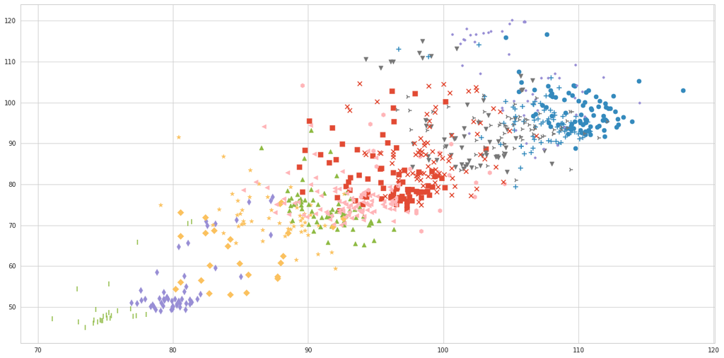

```python
#Visualization after using kmeans clutering
data_visualization(enc,clusters_ae)
```

Nhìn hình ta thấy, dữ liệu vẫn còn chồng chất lên nhau ở một vài cụm.

# Compare result after using dimensional reduction algorithms:

```python
comparison_table = pd.DataFrame.from_dict({'accuracy_score': [y_data_accuracy,y_pca_accuracy,y_tsne_accuracy,y_kpca_accuracy,y_ica_accuracy,y_ae_accuracy],
                              'rand_score': [y_data_rand_score,y_pca_rand_score,y_tsne_rand_score,y_kpca_rand_score,y_ica_rand_score,y_ae_rand_score],
                              'silhouette_score': [y_data_silhouette_score,y_pca_silhouette_score,y_tsne_silhouette_score,y_kpca_silhouette_score,y_ica_silhouette_score,y_ae_silhouette_score],
                              'time (second)':[time_stat,time_pca,time_tsne,time_kpca,time_ica,time_ec]}, orient='index',
                              columns=['baseline (Stat Feats)','PCA','t-SNE','KPCA','ICA','Autoencoder'])
comparison_table
```

|  | baseline (Stat Feats) | PCA | t-SNE | KPCA | ICA | Autoencoder |
| --- | --- | --- | --- | --- | --- | --- |
| accuracy_score | 0.103695 | 0.104887 | 0.097735 | 0.160906 | 0.110846 | 0.059595 |
| rand_score | 0.872220 | 0.864437 | 0.877147 | 0.864821 | 0.859738 | 0.857527 |
| silhouette_score | 0.251157 | 0.330348 | 0.385783 | 0.323244 | 0.311246 | 0.360976 |
| time (second) | 0.023023 | 0.034901 | 46.588132 | 0.040848 | 0.023330 | 0.775553 |

**Tổng kết**